# 16S rRNA gene processing and taxonomic assignment on DNA extracted from samples obtained in Oman in 2018

Source file: OM18_16S_taxa_assignment_DADA2_Silva138_Bayesian.Rmd

Daniel Nothaft

30 Apr 2020

# 1 DADA2 Setup

Data processed using the packages [dada2](https://benjjneb.github.io/dada2/index.html) version 1.14.1.

Following [this tutorial](https://benjjneb.github.io/dada2/tutorial.html)

Load packages

```r
library(dada2)#; packageVersion("dada2") # processing sequence data
library(tidyverse) # manipulating strings and data frames
```

```r
# global knitting options for automatic saving of all plots as .png and .pdf. Also sets cache directory.
knitr::opts_chunk$set(
  dev = c("png", "pdf"), fig.keep = "all",
  dev.args = list(pdf = list(encoding = "WinAnsi", useDingbats = FALSE)),
  fig.path = file.path("fig_output/", paste0(gsub("\\.[Rr]md", "/", knitr::current_input()))),
  cache.path = file.path("cache/", paste0(gsub("\\.[Rr]md", "/", knitr::current_input())))
)
```

Define where the fastq file are and check what the files are. These fastq files were previously demultiplexed with QIIME2.

```r
path <- "~/Desktop/Boulder/2018_fall/molecular_methods_ebio/Molecular-Methods/dada2/attempt_1_files/demux_extracted_OM18/data_for_Oman_CH4_stable_isotope_paper/fastq_files" # CHANGE ME to the directory containing the fastq files after unzipping.
list.files(path)
```

```
##  [1] "CM2A_45_9D_25_L001_R1_001.fastq"   "CM2A_45_9D_25_L001_R2_001.fastq"
##  [3] "NSHQ14_45_7J_32_L001_R1_001.fastq" "NSHQ14_45_7J_32_L001_R2_001.fastq"
##  [5] "NSHQ4_S_11D_18_L001_R1_001.fastq"  "NSHQ4_S_11D_18_L001_R2_001.fastq"
##  [7] "NTC_1_43_L001_R1_001.fastq"        "NTC_1_43_L001_R2_001.fastq"
##  [9] "NTC_10_50_L001_R1_001.fastq"       "NTC_10_50_L001_R2_001.fastq"
## [11] "NTC_11_46_L001_R1_001.fastq"       "NTC_11_46_L001_R2_001.fastq"
## [13] "NTC_12_21_L001_R1_001.fastq"       "NTC_12_21_L001_R2_001.fastq"
## [15] "NTC_13_48_L001_R1_001.fastq"       "NTC_13_48_L001_R2_001.fastq"
## [17] "NTC_14_37_L001_R1_001.fastq"       "NTC_14_37_L001_R2_001.fastq"
## [19] "NTC_15_44_L001_R1_001.fastq"       "NTC_15_44_L001_R2_001.fastq"
## [21] "NTC_16_29_L001_R1_001.fastq"       "NTC_16_29_L001_R2_001.fastq"
## [23] "NTC_17_41_L001_R1_001.fastq"       "NTC_17_41_L001_R2_001.fastq"
## [25] "NTC_18_54_L001_R1_001.fastq"       "NTC_18_54_L001_R2_001.fastq"
## [27] "NTC_19_42_L001_R1_001.fastq"       "NTC_19_42_L001_R2_001.fastq"
## [29] "NTC_2_49_L001_R1_001.fastq"        "NTC_2_49_L001_R2_001.fastq"
```

[output cut: 17 more lines]

Now we read in the names of the fastq files, and perform some string manipulation to get matched lists of the forward and reverse fastq files.

```r
# Forward and reverse fastq filenames have format: SAMPLENAME_R1_001.fastq and SAMPLENAME_R2_001.fastq
fnFs <- sort(list.files(path, pattern="_R1_001.fastq", full.names = TRUE))
fnRs <- sort(list.files(path, pattern="_R2_001.fastq", full.names = TRUE))
```

# 2 Extract sample names

```r
# Extract sample names, assuming filenames have format: SAMPLENAME_XXX.fastq
sample.names <- sapply(strsplit(basename(fnFs), "_L001"), `[`, 1)

sample.names
```

```
##  [1] "CM2A_45_9D_25"   "NSHQ14_45_7J_32" "NSHQ4_S_11D_18"  "NTC_1_43"
##  [5] "NTC_10_50"       "NTC_11_46"       "NTC_12_21"       "NTC_13_48"
##  [9] "NTC_14_37"       "NTC_15_44"       "NTC_16_29"       "NTC_17_41"
## [13] "NTC_18_54"       "NTC_19_42"       "NTC_2_49"        "NTC_20_45"
## [17] "NTC_3_33"        "NTC_4_53"        "NTC_5_36"        "NTC_6_38"
## [21] "NTC_7_40"        "NTC_8_51"        "NTC_9_52"        "OM18_BC_31"
## [25] "OM18_BD_6"       "OM18_BJ_47"      "WAB103_45_10J_9" "WAB104_45_5C_26"
## [29] "WAB105_45_6D_17" "WAB188_45_4J_13" "WAB55_45_8C_12"  "WAB71_45_3D_7"
```

My fastq files had extra digits on the back end of the sample names, so this next chunk trims those from the sample names.

```r
sample.names.rev <- sapply(lapply(strsplit(sample.names, NULL), rev), paste, collapse="") # reverse sample name strings because many stringr function like to work from start of string

sample.names.rev.nums.cut <- sub("^[^_]*", "", sample.names.rev) # cut the strings up til first underscore

sample.names.rev.nums.cut <- str_remove(sample.names.rev.nums.cut, "_") # remove underscore

sample.names <- sapply(lapply(strsplit(sample.names.rev.nums.cut, NULL), rev), paste, collapse="") # reverse cut strings back into original order

sample.names # print
```

```
##  [1] "CM2A_45_9D"    "NSHQ14_45_7J"  "NSHQ4_S_11D"   "NTC_1"
##  [5] "NTC_10"        "NTC_11"        "NTC_12"        "NTC_13"
##  [9] "NTC_14"        "NTC_15"        "NTC_16"        "NTC_17"
## [13] "NTC_18"        "NTC_19"        "NTC_2"         "NTC_20"
## [17] "NTC_3"         "NTC_4"         "NTC_5"         "NTC_6"
## [21] "NTC_7"         "NTC_8"         "NTC_9"         "OM18_BC"
## [25] "OM18_BD"       "OM18_BJ"       "WAB103_45_10J" "WAB104_45_5C"
## [29] "WAB105_45_6D"  "WAB188_45_4J"  "WAB55_45_8C"   "WAB71_45_3D"
```

# 3 Inspect read quality profiles

We start by visualizing the quality profiles of the forward reads:

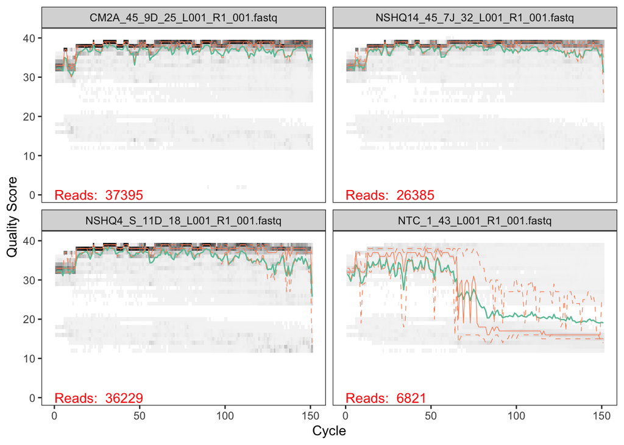

```r
plotQualityProfile(fnFs[1:4])
```

In gray-scale is a heat map of the frequency of each quality score at each base position. The difference between a quality score of 40 and a quality score of 20 is an expected error rate of 1 in 10,000 vs 1 in 100 ([Phred](https://en.wikipedia.org/wiki/Phred_quality_score)). The median quality score at each position is shown by the green line, and the quartiles of the quality score distribution by the orange lines. The red line shows the scaled proportion of reads that extend to at least that position (this is more useful for other sequencing technologies, as Illumina reads are typically all the same lenghth, hence the flat red line).

Now we visualize the quality profile of the reverse reads:

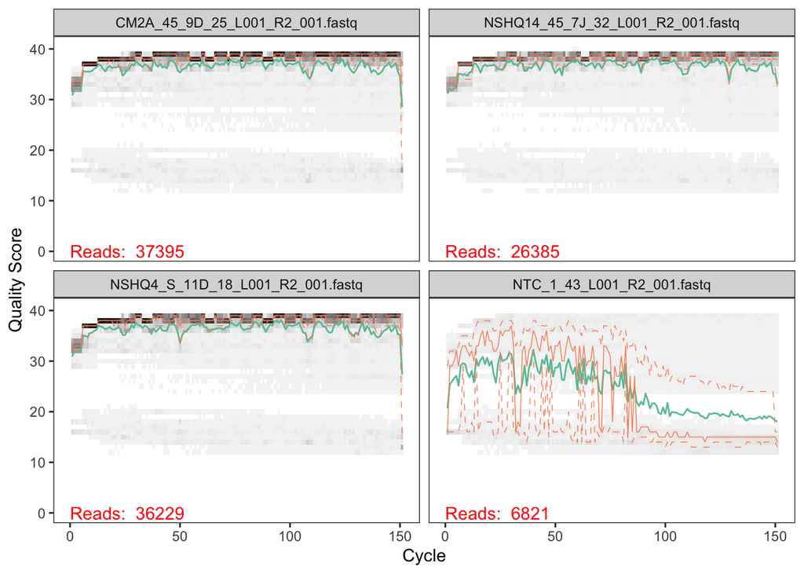

```r
plotQualityProfile(fnRs[1:4])
```

The reverse reads also look to be of good quality.

# 4 Filter reads

Make folder for filtered reads and rename files

```r
# Place filtered files in filtered/ subdirectory
filtFs <- file.path(path, "filtered", paste0(sample.names, "_F_filt.fastq.gz"))
filtRs <- file.path(path, "filtered", paste0(sample.names, "_R_filt.fastq.gz"))
```

Filter arguments:

1. truncLen sets the length at which reads should be truncated which is also the minimum length of a read required to pass the filter for the (forward,reverse) reads, default is 0 and no reads are truncated.
2. maxN sets the maximum number of N reads allowed in a sequence, by default dada2 doesn’t allow any Ns
3. maxEE sets the maximum number of expected errors that are accepted before a read is tossed. default is infinity.
4. truncQ truncates the read once a quality score at or below truncQ is hit.
5. rm.phix discards reads that match the phiX genome, default is TRUE
6. matchIDs default is FALSE which assumes that paired end reads are in matching order, TRUE only outputs reads where both forward and reverse can be found and matched.
7. compress default is TRUE if fastq files are gzipped
8. multithread allows for parallelization, default is FALSE

We’ll use standard filtering parameters: maxN=0 (DADA2 requires no Ns), truncQ=2, rm.phix=TRUE and maxEE=2. The maxEE parameter sets the maximum number of “expected errors” allowed in a read, which is a better filter than simply averaging quality scores. (https://academic.oup.com/bioinformatics/article/31/21/3476/194979)

```r
out <- filterAndTrim(fnFs, filtFs, fnRs, filtRs, truncLen=c(145,145),
              maxN=0, maxEE=c(2,2), truncQ=2, rm.phix=TRUE,
              compress=TRUE, multithread=TRUE) # On Windows set multithread=FALSE
```

```
## Creating output directory: /Users/melo.d/Desktop/Boulder/2018_fall/molecular_methods_ebio/Molecular-Methods/dada2/attempt_1_files/demux_extracted_OM18/data_for_Oman_CH4_stable_isotope_paper/fastq_files/filtered
```

```r
head(out)
```

```
##                                   reads.in reads.out
## CM2A_45_9D_25_L001_R1_001.fastq      37395     35672
## NSHQ14_45_7J_32_L001_R1_001.fastq    26385     25488
## NSHQ4_S_11D_18_L001_R1_001.fastq     36229     34512
## NTC_1_43_L001_R1_001.fastq            6821       812
## NTC_10_50_L001_R1_001.fastq           4427      1942
## NTC_11_46_L001_R1_001.fastq           2808      2258
```

# 5 Learn errors

The DADA2 algorithm makes use of a parametric error model (err) and every amplicon dataset has a different set of error rates. The learnErrors method learns this error model from the data, by alternating estimation of the error rates and inference of sample composition until they converge on a jointly consistent solution. As in many machine-learning problems, the algorithm must begin with an initial guess, for which the maximum possible error rates in this data are used (the error rates if only the most abundant sequence is correct and all the rest are errors).

```r
errF <- learnErrors(filtFs, multithread=TRUE)
```

```
## 50155645 total bases in 345901 reads from 32 samples will be used for learning the error rates.
```

Reverse:

```r
errR <- learnErrors(filtRs, multithread=TRUE)
```

```
## 50155645 total bases in 345901 reads from 32 samples will be used for learning the error rates.
```

Visualize estimated error rates.

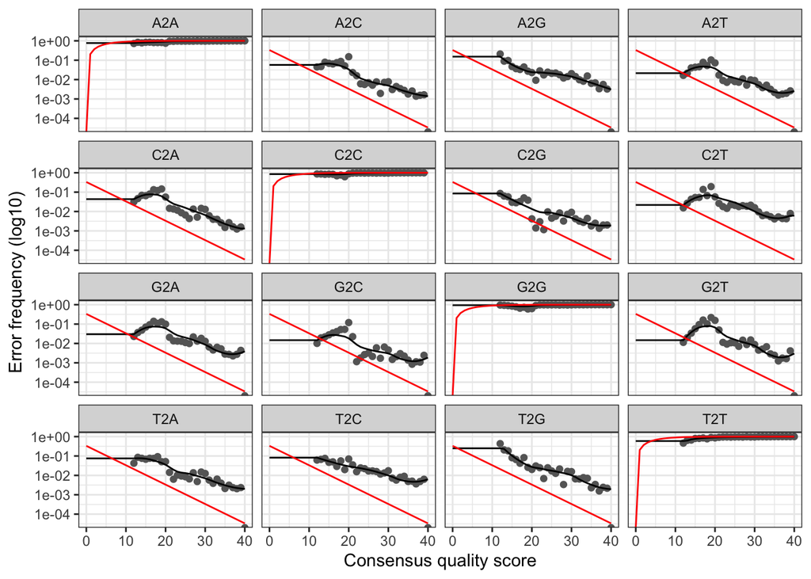

```r
plotErrors(errF, nominalQ=TRUE)
```

The error rates for each possible transition (A→C, A→G, …) are shown. Points are the observed error rates for each consensus quality score. The black line shows the estimated error rates after convergence of the machine-learning algorithm. The red line shows the error rates expected under the nominal definition of the Q-score. Here the estimated error rates (black line) are a good fit to the observed rates (points), and the error rates drop with increased quality as expected. Everything looks reasonable and we proceed with confidence.

## 5.1 Dereplication

Dereplication combines all identical sequencing reads into into “unique sequences” with a corresponding “abundance” equal to the number of reads with that unique sequence. Dereplication substantially reduces computation time by eliminating redundant comparisons.

Dereplication in the DADA2 pipeline has one crucial addition from other pipelines: DADA2 retains a summary of the quality information associated with each unique sequence. The consensus quality profile of a unique sequence is the average of the positional qualities from the dereplicated reads. These quality profiles inform the error model of the subsequent sample inference step, significantly increasing DADA2’s accuracy.

```r
derepFs <- derepFastq(filtFs, verbose=TRUE)
derepRs <- derepFastq(filtRs, verbose=TRUE)
# Name the derep-class objects by the sample names
names(derepFs) <- sample.names
names(derepRs) <- sample.names
```

# 6 Sample inference

We are now ready to apply [the core sample inference algorithm](https://www.nature.com/articles/nmeth.3869#methods) to the dereplicated data.

```r
dadaFs <- dada(derepFs, err=errF, multithread=TRUE)
```

```
## Sample 1 - 35672 reads in 6783 unique sequences.
## Sample 2 - 25488 reads in 5499 unique sequences.
## Sample 3 - 34512 reads in 9399 unique sequences.
## Sample 4 - 812 reads in 439 unique sequences.
## Sample 5 - 1942 reads in 1043 unique sequences.
## Sample 6 - 2258 reads in 523 unique sequences.
## Sample 7 - 2247 reads in 1053 unique sequences.
## Sample 8 - 3240 reads in 1615 unique sequences.
## Sample 9 - 1366 reads in 532 unique sequences.
## Sample 10 - 297 reads in 184 unique sequences.
## Sample 11 - 881 reads in 463 unique sequences.
## Sample 12 - 1393 reads in 893 unique sequences.
## Sample 13 - 250 reads in 158 unique sequences.
## Sample 14 - 559 reads in 517 unique sequences.
## Sample 15 - 4835 reads in 1562 unique sequences.
## Sample 16 - 674 reads in 377 unique sequences.
## Sample 17 - 1682 reads in 707 unique sequences.
## Sample 18 - 249 reads in 106 unique sequences.
## Sample 19 - 924 reads in 317 unique sequences.
## Sample 20 - 1017 reads in 361 unique sequences.
## Sample 21 - 1104 reads in 416 unique sequences.
## Sample 22 - 1096 reads in 512 unique sequences.
## Sample 23 - 120 reads in 70 unique sequences.
## Sample 24 - 4634 reads in 1291 unique sequences.
## Sample 25 - 2034 reads in 1017 unique sequences.
## Sample 26 - 1063 reads in 801 unique sequences.
## Sample 27 - 29455 reads in 11896 unique sequences.
## Sample 28 - 41822 reads in 15038 unique sequences.
## Sample 29 - 36055 reads in 7478 unique sequences.
## Sample 30 - 37100 reads in 12178 unique sequences.
## Sample 31 - 29361 reads in 9510 unique sequences.
## Sample 32 - 41759 reads in 10008 unique sequences.
```

```r
dadaRs <- dada(derepRs, err=errR, multithread=TRUE)
```

```
## Sample 1 - 35672 reads in 6413 unique sequences.
## Sample 2 - 25488 reads in 5245 unique sequences.
## Sample 3 - 34512 reads in 7098 unique sequences.
## Sample 4 - 812 reads in 405 unique sequences.
## Sample 5 - 1942 reads in 926 unique sequences.
## Sample 6 - 2258 reads in 478 unique sequences.
## Sample 7 - 2247 reads in 969 unique sequences.
## Sample 8 - 3240 reads in 1558 unique sequences.
## Sample 9 - 1366 reads in 531 unique sequences.
## Sample 10 - 297 reads in 178 unique sequences.
## Sample 11 - 881 reads in 442 unique sequences.
## Sample 12 - 1393 reads in 843 unique sequences.
## Sample 13 - 250 reads in 157 unique sequences.
## Sample 14 - 559 reads in 513 unique sequences.
## Sample 15 - 4835 reads in 1271 unique sequences.
## Sample 16 - 674 reads in 391 unique sequences.
## Sample 17 - 1682 reads in 561 unique sequences.
## Sample 18 - 249 reads in 106 unique sequences.
## Sample 19 - 924 reads in 238 unique sequences.
## Sample 20 - 1017 reads in 265 unique sequences.
## Sample 21 - 1104 reads in 423 unique sequences.
## Sample 22 - 1096 reads in 414 unique sequences.
## Sample 23 - 120 reads in 60 unique sequences.
## Sample 24 - 4634 reads in 1151 unique sequences.
## Sample 25 - 2034 reads in 1021 unique sequences.
## Sample 26 - 1063 reads in 790 unique sequences.
## Sample 27 - 29455 reads in 10981 unique sequences.
## Sample 28 - 41822 reads in 14043 unique sequences.
## Sample 29 - 36055 reads in 7201 unique sequences.
## Sample 30 - 37100 reads in 11254 unique sequences.
## Sample 31 - 29361 reads in 8313 unique sequences.
## Sample 32 - 41759 reads in 9902 unique sequences.
```

Inspecting the returned dada-class object:

```r
dadaFs[[1]]
```

```
## dada-class: object describing DADA2 denoising results
## 123 sequence variants were inferred from 6783 input unique sequences.
## Key parameters: OMEGA_A = 1e-40, OMEGA_C = 1e-40, BAND_SIZE = 16
```

# 7 Merging paired ends

We now merge the forward and reverse reads together to obtain the full denoised sequences. Merging is performed by aligning the denoised forward reads with the reverse-complement of the corresponding denoised reverse reads, and then constructing the merged “contig” sequences. By default, merged sequences are only output if the forward and reverse reads overlap by at least 12 bases, and are identical to each other in the overlap region.

```r
mergers <- mergePairs(dadaFs, derepFs, dadaRs, derepRs, verbose=TRUE)
```

```
## 34639 paired-reads (in 157 unique pairings) successfully merged out of 35170 (in 407 pairings) input.
```

```
## 24678 paired-reads (in 123 unique pairings) successfully merged out of 25023 (in 304 pairings) input.
```

```
## 31929 paired-reads (in 206 unique pairings) successfully merged out of 33830 (in 531 pairings) input.
```

```
## 542 paired-reads (in 3 unique pairings) successfully merged out of 542 (in 3 pairings) input.
```

```
## 1289 paired-reads (in 3 unique pairings) successfully merged out of 1290 (in 4 pairings) input.
```

```
## 2222 paired-reads (in 6 unique pairings) successfully merged out of 2226 (in 9 pairings) input.
```

```
## 1730 paired-reads (in 65 unique pairings) successfully merged out of 1887 (in 116 pairings) input.
```

```
## 2198 paired-reads (in 105 unique pairings) successfully merged out of 2610 (in 223 pairings) input.
```

```
## 1126 paired-reads (in 22 unique pairings) successfully merged out of 1175 (in 36 pairings) input.
```

```
## 154 paired-reads (in 13 unique pairings) successfully merged out of 161 (in 18 pairings) input.
```

```
## 603 paired-reads (in 21 unique pairings) successfully merged out of 646 (in 33 pairings) input.
```

```
## 739 paired-reads (in 61 unique pairings) successfully merged out of 974 (in 121 pairings) input.
```

```
## 136 paired-reads (in 12 unique pairings) successfully merged out of 144 (in 15 pairings) input.
```

```
## 63 paired-reads (in 2 unique pairings) successfully merged out of 65 (in 3 pairings) input.
```

```
## 4654 paired-reads (in 12 unique pairings) successfully merged out of 4715 (in 24 pairings) input.
```

```
## 390 paired-reads (in 4 unique pairings) successfully merged out of 390 (in 4 pairings) input.
```

```
## 1430 paired-reads (in 8 unique pairings) successfully merged out of 1441 (in 14 pairings) input.
```

```
## 180 paired-reads (in 1 unique pairings) successfully merged out of 193 (in 2 pairings) input.
```

```
## 903 paired-reads (in 2 unique pairings) successfully merged out of 903 (in 2 pairings) input.
```

```
## 991 paired-reads (in 4 unique pairings) successfully merged out of 998 (in 7 pairings) input.
```

```
## 888 paired-reads (in 3 unique pairings) successfully merged out of 890 (in 5 pairings) input.
```

```
## 901 paired-reads (in 4 unique pairings) successfully merged out of 903 (in 5 pairings) input.
```

```
## 78 paired-reads (in 4 unique pairings) successfully merged out of 78 (in 4 pairings) input.
```

```
## 4539 paired-reads (in 20 unique pairings) successfully merged out of 4562 (in 30 pairings) input.
```

```
## 1406 paired-reads (in 14 unique pairings) successfully merged out of 1415 (in 20 pairings) input.
```

```
## 376 paired-reads (in 3 unique pairings) successfully merged out of 376 (in 3 pairings) input.
```

```
## 24880 paired-reads (in 762 unique pairings) successfully merged out of 27530 (in 1547 pairings) input.
```

```
## 36496 paired-reads (in 686 unique pairings) successfully merged out of 39804 (in 1732 pairings) input.
```

```
## 34577 paired-reads (in 222 unique pairings) successfully merged out of 35252 (in 554 pairings) input.
```

```
## 33195 paired-reads (in 529 unique pairings) successfully merged out of 35086 (in 1323 pairings) input.
```

```
## 27261 paired-reads (in 249 unique pairings) successfully merged out of 28662 (in 617 pairings) input.
```

```
## 40582 paired-reads (in 161 unique pairings) successfully merged out of 41217 (in 396 pairings) input.
```

```r
# Inspect the merger data.frame from the first sample
head(mergers[[1]])
```

|  | sequence | abundance | forward | reverse | nmatch | nmismatch | nindel | prefer | accept |
| --- | --- | --- | --- | --- | --- | --- | --- | --- | --- |
| 1 | TACGTAGGGGGCGAGCGTTGTCCGGAATTACTGGGCGTAAAGGGCGAGTAGGCGGTTTAA…… | 7990 | 1 | 1 | 37 | 0 | 0 | 1 | TRUE |
| 2 | TACGTAGGGGGCGAGCGTTGTCCGGAATTATTGGGCGTAAAGGGCGTGTAGGCGGCCGAT…… | 4973 | 3 | 2 | 37 | 0 | 0 | 2 | TRUE |
| 3 | TACGGAGGGAGCTAGCGTTGTTCGGAATTACTGGGCGTAAAGCGCACGTAGGCGGCTTTT…… | 4959 | 2 | 3 | 37 | 0 | 0 | 2 | TRUE |
| 4 | TACGTAGGGGGCGAGCGTTGTCCGGAATTACTGGGCGTAAAGGGCGAGTAGGCGGTTTAA…… | 4316 | 1 | 4 | 37 | 0 | 0 | 1 | TRUE |
| 5 | TACGTAGGGGGCAAGCGTTGTCCGGAATTATTGGGCGTAAAGGGCGTGTAGGCGGCCGAT…… | 2247 | 4 | 2 | 37 | 0 | 0 | 2 | TRUE |
| 6 | TACGTAGGGTGCGAGCGTTAATCGGAATTACTGGGCGTAAAGCGTGCGCAGGCGGTTTTG…… | 1569 | 5 | 5 | 37 | 0 | 0 | 2 | TRUE |

The mergers object is a list of data.frames from each sample. Each data.frame contains the merged sequence, its abundance, and the indices of the forward and reverse sequence variants that were merged. Paired reads that did not exactly overlap were removed by mergePairs, further reducing spurious output.

# 8 Construct sequence table

We can now construct an amplicon sequence variant table (ASV) table, a higher-resolution version of the OTU table produced by traditional methods.

```r
# create sequence table
seqtab <- makeSequenceTable(mergers)
# show dimenions of sequence table
dim(seqtab)
```

```
## [1]   32 2977
```

```r
# Inspect distribution of sequence lengths
table(nchar(getSequences(seqtab)))
```

```
##
##  204  220  221  227  246  249  250  251  252  253  254  255  256  258  259  272
##    1    1    3    1    1    4    6    6   50 2514  337   25    9    2    1    1
##  273  274  276  278
##   10    2    2    1
```

This table shows the number of sequences in the dataset of various lengths. Here, you want to check that the lengths of our merged sequences all fall within the expected range for your amplicon. The sequences in this dataset range from 204-278 bp length, which seems reasonable.

# 9 Remove chimeras

The core dada method corrects substitution and indel errors, but chimeras remain. Fortunately, the accuracy of the sequence variants after denoising makes identifying chimeras simpler than it is when dealing with fuzzy OTUs. Chimeric sequences are identified if they can be exactly reconstructed by combining a left-segment and a right-segment from two more abundant “parent” sequences.

```r
# remove chimeras
seqtab.nochim <- removeBimeraDenovo(seqtab, method="consensus", multithread=TRUE, verbose=TRUE)
```

```
## Identified 287 bimeras out of 2977 input sequences.
```

```r
# show dimensions of resulting dataframe
dim(seqtab.nochim)
```

```
## [1]   32 2690
```

```r
sum(seqtab.nochim)/sum(seqtab)
```

```
## [1] 0.9806729
```

# 10 Check pipeline filtering by step

Hopefully you kept most of the input reads, and there shouldn’t be one step where most of the reads were lost.

```r
getN <- function(x) sum(getUniques(x))
track <- cbind(out, sapply(dadaFs, getN), sapply(dadaRs, getN), sapply(mergers, getN), rowSums(seqtab.nochim))
# If processing a single sample, remove the sapply calls: e.g. replace sapply(dadaFs, getN) with getN(dadaFs)
colnames(track) <- c("input", "filtered", "denoisedF", "denoisedR", "merged", "nonchim")
rownames(track) <- sample.names
head(track)
```

```
##              input filtered denoisedF denoisedR merged nonchim
## CM2A_45_9D   37395    35672     35324     35420  34639   32420
## NSHQ14_45_7J 26385    25488     25183     25238  24678   24533
## NSHQ4_S_11D  36229    34512     34083     34159  31929   30810
## NTC_1         6821      812       545       545    542     542
## NTC_10        4427     1942      1291      1296   1289    1289
## NTC_11        2808     2258      2229      2242   2222    2222
```

# 11 Assign taxonomy

It is common at this point, especially in 16S/18S/ITS amplicon sequencing, to assign taxonomy to the sequence variants. The DADA2 package provides a native implementation of the naive Bayesian classifier method for this purpose. The assignTaxonomy function takes as input a set of sequences to be classified and a training set of reference sequences with known taxonomy, and outputs taxonomic assignments with at least minBoot bootstrap confidence.

Here, we use the Silva 138 training set.

```r
taxa_Silva <- assignTaxonomy(seqtab.nochim, "~/Desktop/Boulder/2018_fall/molecular_methods_ebio/Molecular-Methods/dada2/silva_nr_v138_train_set.fa.gz", multithread=TRUE)
```

Extensions: The dada2 package also implements a method to make species level assignments based on exact matching between ASVs and sequenced reference strains. Recent analysis suggests that exact matching (or 100% identity) is the only appropriate way to assign species to 16S gene fragments.

```r
taxa_Silva <- addSpecies(taxa_Silva, "/Users/melo.d/Desktop/Boulder/2018_fall/molecular_methods_ebio/Molecular-Methods/dada2/silva_species_assignment_v138.fa.gz")
```

Let’s inspect the taxonomic assignments:

```r
taxa.print <- taxa_Silva # Removing sequence rownames for display only
rownames(taxa.print) <- NULL
head(taxa.print)
```

```
##      Kingdom    Phylum           Class
## [1,] "Bacteria" "Proteobacteria" "Gammaproteobacteria"
## [2,] "Bacteria" "Proteobacteria" "Alphaproteobacteria"
## [3,] "Bacteria" "Deinococcota"   "Deinococci"
## [4,] "Bacteria" "Nitrospirota"   "Thermodesulfovibrionia"
## [5,] "Bacteria" "Firmicutes"     "Thermoanaerobacteria"
## [6,] "Bacteria" "Proteobacteria" "Gammaproteobacteria"
##      Order                    Family              Genus              Species
## [1,] "Salinisphaerales"       "Solimonadaceae"    "Solimonas"        "flava"
## [2,] "Rhizobiales"            "Xanthobacteraceae" "Rhodopseudomonas" NA
## [3,] "Thermales"              "Thermaceae"        "Meiothermus"      NA
## [4,] NA                       NA                  NA                 NA
## [5,] "Thermoanaerobacterales" "SRB2"              NA                 NA
## [6,] "Burkholderiales"        "Comamonadaceae"    "Brachymonas"      NA
```

# 12 Create output tables

(courtesy of Mike Lee aka Astrobio Mike)

```r
 # giving our seq headers more manageable names (ASV_1, ASV_2...)
asv_seqs <- colnames(seqtab.nochim)
asv_headers <- vector(dim(seqtab.nochim)[2], mode="character")

for (i in 1:dim(seqtab.nochim)[2]) {
  asv_headers[i] <- paste(">ASV", i, sep="_")
}

  # making and writing out a fasta of our final ASV seqs:
asv_fasta <- c(rbind(asv_headers, asv_seqs))
write(asv_fasta, "ASVs_Silva_Bayes.fa")

  # count table:
asv_tab <- t(seqtab.nochim)
row.names(asv_tab) <- sub(">", "", asv_headers)
write.table(asv_tab, "ASVs_counts_Silva_Bayes.txt", sep="\t", quote=F)

  # tax table:
asv_tax <- taxa_Silva
row.names(asv_tax) <- sub(">", "", asv_headers)
write.table(asv_tax, "ASVs_taxonomy_Silva_Bayes.txt", sep="\t", quote=F)
```

DBN making these taxa tables in format mctoolsr will accept

```r
asv_tax_one_string <- as.data.frame(asv_tax) # make taxa table a dataframe

# make a single string out of all the taxa levels
asv_tax_one_string$taxonomy <- paste0("k__", asv_tax_one_string$Kingdom, "; p__", asv_tax_one_string$Phylum, "; c__", asv_tax_one_string$Class, "; o__", asv_tax_one_string$Order, "; f__", asv_tax_one_string$Family, "; g__", asv_tax_one_string$Genus, "; s__", asv_tax_one_string$Species)

asv_IDs_tax <- as.data.frame(rownames(asv_tax_one_string)) # make a dataframe of ASV ID's
colnames(asv_IDs_tax) <- c("#OTU ID") # Add ASV ID's to taxa table as a row

asv_tax_one_string <- bind_cols(asv_IDs_tax,  asv_tax_one_string) # adding together data frames containing ASV ID's and the single string taxonomic classification

asv_tax_one_string <- asv_tax_one_string %>% select(-Kingdom, -Phylum, -Class, -Order, -Family, -Genus, -Species) # remove rows containing taxonomic classification by individual taxonomic levels

asv_tab_df <- as.data.frame(asv_tab) # convert table of ASV counts to dataframe

asv_IDs_asv_tab <- as.data.frame(rownames(asv_tab_df)) # make dataframe of ASV ID's
colnames(asv_IDs_asv_tab) <- ("#OTU ID") # Name column containing ASV ID's

asv_tab_df <- bind_cols(asv_IDs_asv_tab,  asv_tab_df) # Add together dataframes of ASV ID's and ASV counts

tax_tab_for_mctoolsr_Silva <- asv_tab_df %>% right_join(asv_tax_one_string, by = '#OTU ID') # join data frames of taxonomic classifications and counts

head(tax_tab_for_mctoolsr_Silva) # print first few rows
```

|  | #OTU ID | CM2A_45_9D | NSHQ14_45_7J | NSHQ4_S_11D | NTC_1 | NTC_10 | NTC_11 | NTC_12 | NTC_13 | NTC_14 | NTC_15 | NTC_16 | NTC_17 | NTC_18 | NTC_19 | NTC_2 | NTC_20 | NTC_3 | NTC_4 | NTC_5 | NTC_6 | NTC_7 | NTC_8 | NTC_9 | OM18_BC | OM18_BD | OM18_BJ | WAB103_45_10J | WAB104_45_5C | … |
| --- | --- | --- | --- | --- | --- | --- | --- | --- | --- | --- | --- | --- | --- | --- | --- | --- | --- | --- | --- | --- | --- | --- | --- | --- | --- | --- | --- | --- | --- | --- |
| 1 | ASV_1 | 824 | 2759 | 0 | 0 | 0 | 0 | 0 | 0 | 0 | 0 | 0 | 0 | 0 | 0 | 0 | 0 | 0 | 0 | 0 | 0 | 0 | 0 | 0 | 0 | 0 | 0 | 20 | 900 | … |
| 2 | ASV_2 | 167 | 1386 | 0 | 0 | 0 | 0 | 0 | 0 | 0 | 0 | 0 | 0 | 0 | 0 | 0 | 0 | 0 | 0 | 0 | 0 | 0 | 0 | 0 | 0 | 0 | 0 | 72 | 678 | … |
| 3 | ASV_3 | 64 | 338 | 5654 | 0 | 0 | 0 | 0 | 0 | 0 | 0 | 0 | 0 | 0 | 0 | 0 | 0 | 0 | 0 | 0 | 0 | 0 | 0 | 0 | 0 | 0 | 0 | 5 | 0 | … |
| 4 | ASV_4 | 0 | 48 | 1169 | 0 | 0 | 0 | 0 | 0 | 0 | 0 | 0 | 0 | 0 | 0 | 0 | 0 | 0 | 0 | 0 | 0 | 0 | 0 | 0 | 0 | 0 | 0 | 0 | 0 | … |
| 5 | ASV_5 | 7990 | 0 | 0 | 0 | 0 | 0 | 0 | 0 | 0 | 0 | 0 | 0 | 0 | 0 | 0 | 0 | 0 | 0 | 0 | 0 | 0 | 0 | 0 | 0 | 0 | 0 | 70 | 0 | … |
| 6 | ASV_6 | 1569 | 1639 | 0 | 0 | 0 | 0 | 0 | 0 | 0 | 0 | 0 | 0 | 0 | 0 | 0 | 0 | 8 | 0 | 0 | 0 | 0 | 0 | 0 | 0 | 0 | 0 | 579 | 1456 | … |

# 13 Export output table

```r
write.table(tax_tab_for_mctoolsr_Silva, "data_output/tax_tab_DADA2_mctoolsr_OM18_Silva138_Bayes.txt", row.names = FALSE, sep="\t", quote=F) # write a .txt file of the taxa table
```